# Supervised Machine Learning II

Martin Sigrist (21-101-175)

03.06.2023

# Introduction

In this chapter, k-Nearest-Neighbor models are trained for two different sites of Fluxnet. In a first step, the models are trained with data from one site and tested with data from the same site and data from the other site. In the second step, a model is trained with mixed data from both sites and tested with data from both sites individually. The goal is to investigate the generalizability of the models across different sites.

# Load required Libraries

```r
library(tidyverse)
library(lubridate)
library(caret)
library(recipes)
```

# Load external functions

```r
source("../R/eval_model.R")
source("../R/read_data.R")
```

## Read and Clean Data

```r
# Data for Davos site
daily_fluxes_dav <- read_data("../data/FLX_CH-Dav_FLUXNET2015_FULLSET_DD_1997-2014_1-3.csv")
# Data for Laegern site
daily_fluxes_lae <- read_data("../data/FLX_CH-Lae_FLUXNET2015_FULLSET_DD_2004-2014_1-4.csv")
```

## Data spliting

```r
# set random generator seed for reproducibility
set.seed(1982)

# Split data for Davos site (80% for training and 20% for testing)
split <- rsample::initial_split(daily_fluxes_dav, prop = 0.8, strata = "VPD_F")
daily_fluxes_dav_train <- rsample::training(split)
daily_fluxes_dav_test <- rsample::testing(split)

# Split data for Laegern site  (80% for training and 20% for testing)
split <- rsample::initial_split(daily_fluxes_lae, prop = 0.8, strata = "VPD_F")
daily_fluxes_lae_train <- rsample::training(split)
daily_fluxes_lae_test <- rsample::testing(split)
```

# Model for Davos site

## Model and pre-processing formulation

```r
# Use all variables but LW_IN_F
pp_dav <- recipes::recipe(GPP_NT_VUT_REF ~ SW_IN_F + VPD_F + TA_F + VPD_F + PA_F + P_F + WS_F,
                      data = daily_fluxes_dav_train |> drop_na()) |>
  recipes::step_BoxCox(all_predictors()) |>
  recipes::step_center(all_numeric(), -all_outcomes()) |>
  recipes::step_scale(all_numeric(), -all_outcomes())
```

## Hyperparameter tuning

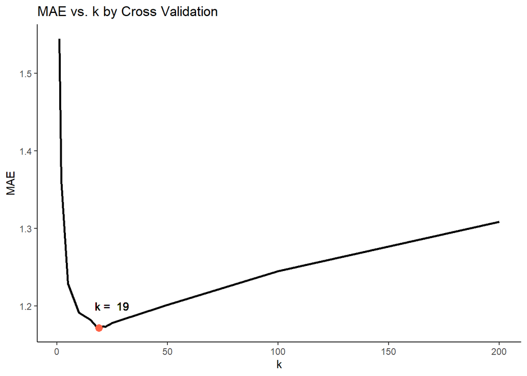

```r
set.seed(42) # Set random number generator seed for reproducibility

# Tune hyperparameter k with cross validation and Mean Absolut Error as metric
suppressWarnings( # Suppress warnings from Box-Cox-Transformation
  mod_knn_dav <- caret::train(
    pp_dav,
    data = daily_fluxes_dav_train |> drop_na(),
    method = "knn",
    trControl = caret::trainControl(method = "cv",
                                    number = 5,
                                    search = "grid"),
    tuneGrid = expand.grid(k = c(1, 2, 5, 10, 15, 18, 19, 20, 21, 22, 23, 24, 25, 50, 100, 200)),
    metric = "MAE"
  )
)

# Create plot
ggplot(
    data = mod_knn_dav$results,
    aes(x = k, y = MAE)) +
  geom_line(linewidth = 1) +
  geom_point(
    data = mod_knn_dav$results |> filter(k == mod_knn_dav$bestTune[1,1]) |> select(k, MAE),
    aes(x = k, y = MAE), size = 3, color = "tomato") +
  geom_text(x=25, y=1.2, label = paste("k = ", mod_knn_dav$bestTune[1,1])) +
  labs(title = "MAE vs. k by Cross Validation",
       x = "k",
       y = "MAE") +
  theme_classic()
```

## Comparision within- and across-site

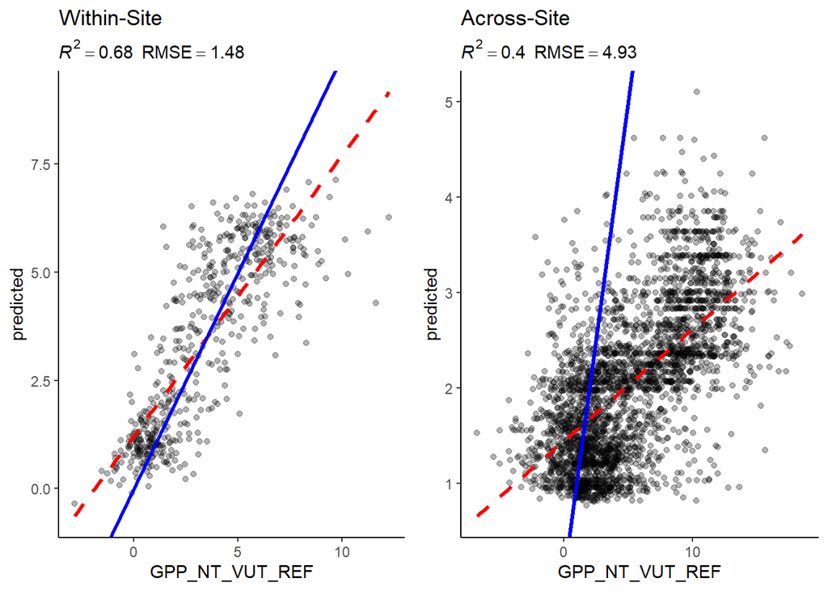

```r
eval_model(mod = mod_knn_dav, df_train = daily_fluxes_dav_test, df_test = daily_fluxes_lae, title_train="Within-Site", title_test="Across-Site")
```

Testing the model with data from the same site gives a similar result as shown in the previous chapter. The accuracy of the model is very bad when applied on data from the other site. The predicted values were smaller than the measured values in a majority of the observations. The range of the training data seems to be too small to cover also the data from the Lägern site.

# Model for Laegern site

## Model and pre-processing formulation

```r
# Use all variables but LW_IN_F
pp_lae <- recipes::recipe(GPP_NT_VUT_REF ~ SW_IN_F + VPD_F + TA_F + VPD_F + PA_F + P_F + WS_F,
                      data = daily_fluxes_lae_train |> drop_na()) |>
  recipes::step_BoxCox(all_predictors()) |>
  recipes::step_center(all_numeric(), -all_outcomes()) |>
  recipes::step_scale(all_numeric(), -all_outcomes())
```

## Hyperparameter tuning

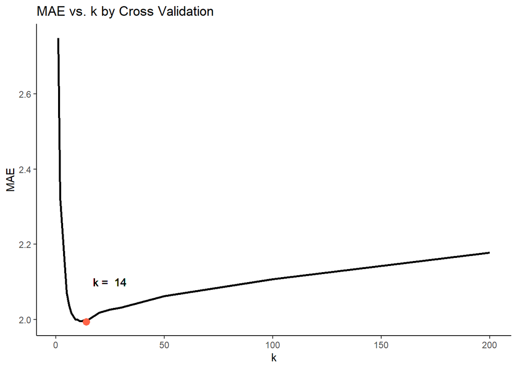

```r
set.seed(42) # Set random number generator seed for reproducibility

# Tune hyperparameter k with cross validation and Mean Absolut Error as metric
suppressWarnings( # Suppress warnings from Box-Cox-Transformation
  mod_knn_lae <- caret::train(
    pp_lae,
    data = daily_fluxes_lae_train |> drop_na(),
    method = "knn",
    trControl = caret::trainControl(method = "cv",
                                    number = 5,
                                    search = "grid"),
    tuneGrid = expand.grid(k = c(1, 2, 5, 6, 7, 8, 9, 10, 11, 12, 13, 14, 15, 20, 25, 30, 50, 100, 200)),
    metric = "MAE"
  )
)

# Create plot
ggplot(
    data = mod_knn_lae$results,
    aes(x = k, y = MAE)) +
  geom_line(linewidth = 1) +
  geom_point(
    data = mod_knn_lae$results |> filter(k == mod_knn_lae$bestTune[1,1]) |> select(k, MAE),
    aes(x = k, y = MAE), size = 3, color = "tomato") +
  geom_text(x=25, y=2.1, label = paste("k = ", mod_knn_lae$bestTune[1,1])) +
  labs(title = "MAE vs. k by Cross Validation",
       x = "k",
       y = "MAE") +
  theme_classic()
```

## Comparision within- and across-site

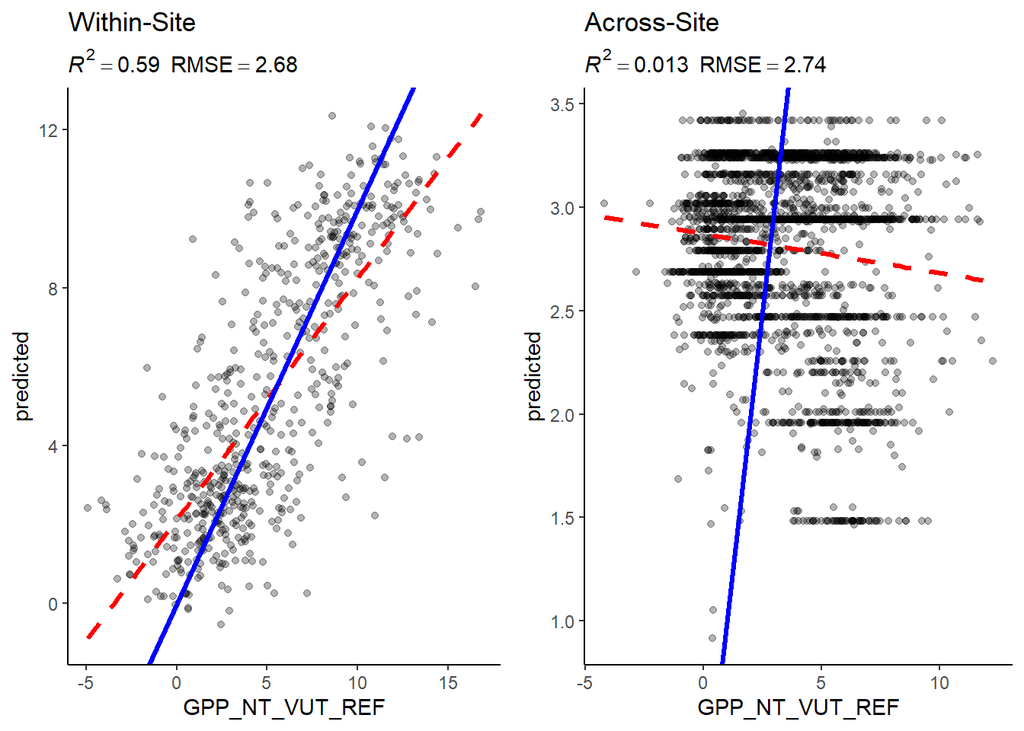

```r
eval_model(mod = mod_knn_lae, df_train = daily_fluxes_lae_test, df_test = daily_fluxes_dav, title_train="Within-Site", title_test="Across-Site")
```

The metrics of the test with data from the same site as the training data were not as good as for the Davos site. The application of the model to the Davos site data gives a totally unusable result. The slope of the linear regression has the wrong sign and the scatter plot shows strange patterns. This model seems to have the same problem as the other one.

# Model trained with combined data

## Combined data from both sites

```r
daily_fluxes_comb_train <- bind_rows(daily_fluxes_dav_train, daily_fluxes_lae_train)
```

## Model and pre-processing formulation

```r
# Use all variables but LW_IN_F
pp_comb <- recipes::recipe(GPP_NT_VUT_REF ~ SW_IN_F + VPD_F + TA_F + VPD_F + PA_F + P_F + WS_F,
                      data = daily_fluxes_comb_train |> drop_na()) |>
  recipes::step_BoxCox(all_predictors()) |>
  recipes::step_center(all_numeric(), -all_outcomes()) |>
  recipes::step_scale(all_numeric(), -all_outcomes())
```

## Hyperparameter tuning

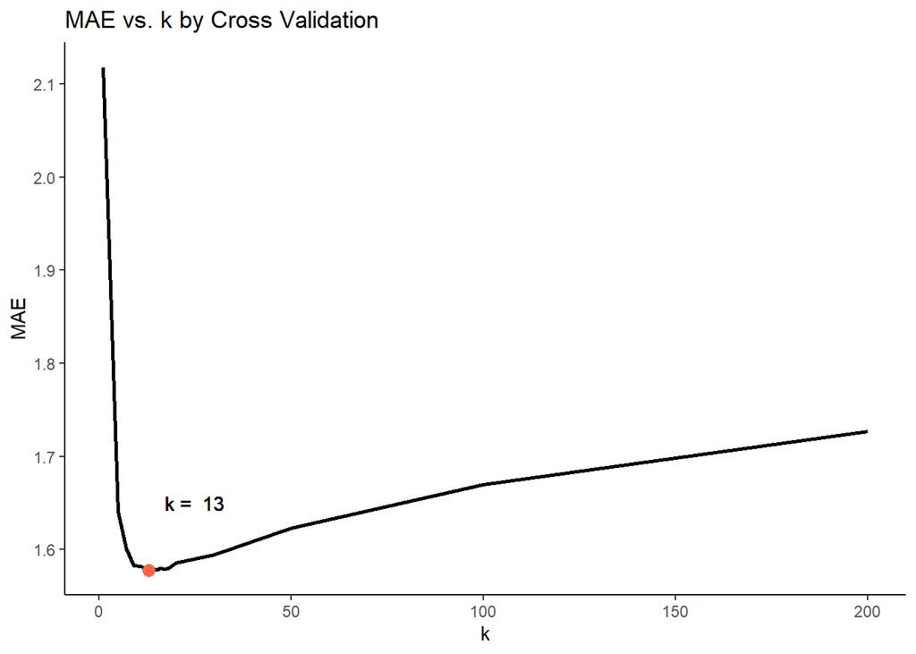

```r
set.seed(42) # Set random number generator seed for reproducibility

# Tune hyperparameter k with cross validation and Mean Absolut Error as metric
suppressWarnings( # Suppress warnings from Box-Cox-Transformation
  mod_knn_comb <- caret::train(
    pp_comb,
    data = daily_fluxes_comb_train |> drop_na(),
    method = "knn",
    trControl = caret::trainControl(method = "cv",
                                    number = 5,
                                    search = "grid"),
    tuneGrid = expand.grid(k = c(1, 5, 7, 9, 11, 13, 14, 15, 16, 17, 18, 20, 25, 30, 50, 100, 200)),
    metric = "MAE"
  )
)

# Create plot
ggplot(
    data = mod_knn_comb$results,
    aes(x = k, y = MAE)) +
  geom_line(linewidth = 1) +
  geom_point(
    data = mod_knn_comb$results |> filter(k == mod_knn_comb$bestTune[1,1]) |> select(k, MAE),
    aes(x = k, y = MAE), size = 3, color = "tomato") +
  geom_text(x=25, y=1.65, label = paste("k = ", mod_knn_comb$bestTune[1,1])) +
  labs(title = "MAE vs. k by Cross Validation",
       x = "k",
       y = "MAE") +
  theme_classic()
```

## Prediction for both sites with combined model

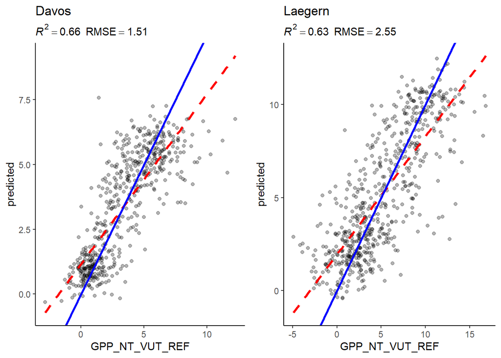

```r
eval_model(mod = mod_knn_comb, df_train = daily_fluxes_dav_test, df_test = daily_fluxes_lae_test, title_train="Davos", title_test="Laegern")
```

A model trained with a combined data set is able to make valid predictions for both sites. For both sites, R<sup>2</sup> and RMSE are similar to the ones that resulted from the models, train with data from one site only.

# Site comparision

## Based on available data

The two sites can be compared based on the available measurements. In this case, the variables of temperature, precipitation and shortwave incoming radiation were compared, because they are strongly relevant for vegetation growth. The calculation does not consider missing values and different number of days per month. Therefor, monthly and yearly mean values and sums are rough estimations only.

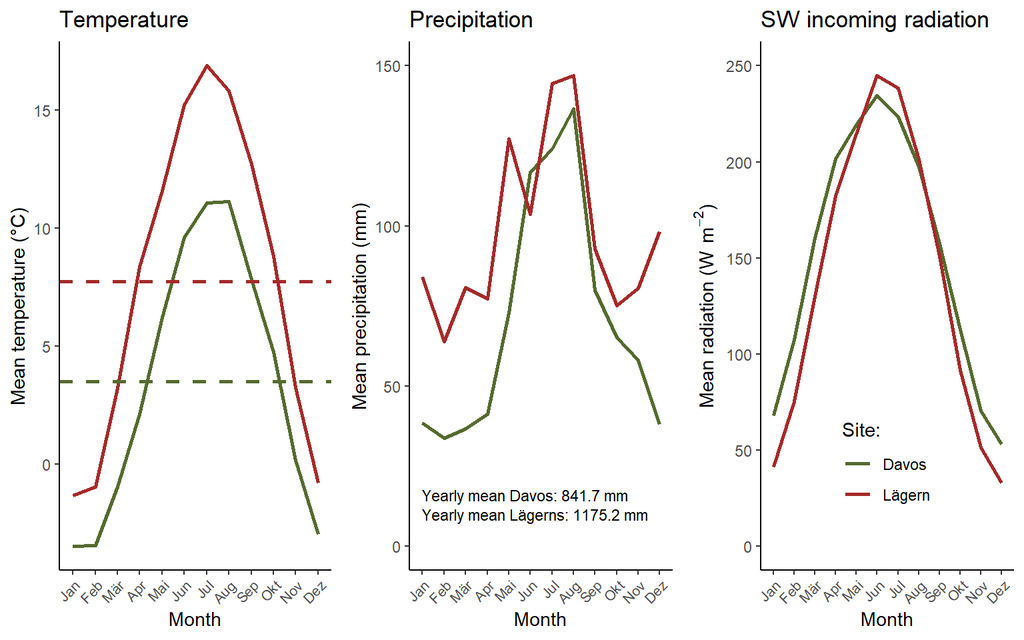

```r
# Prepare data frame for plotting
plot_data_dav <- daily_fluxes_dav |>
  mutate(month = month(TIMESTAMP, label = TRUE), year = year(TIMESTAMP)) |>
  group_by(year, month) |>
  summarise(Temperature = mean(TA_F, na.rm = TRUE),     # Monthly mean temperature
            Precipitation = sum(P_F, na.rm = TRUE),     # Monthly sum of precipitation
            Radiation = mean(SW_IN_F, na.rm = TRUE)) |> # Monthly mean shortwave incoming radiation
  group_by(month) |>
  summarise(Temperature = mean(Temperature, na.rm = TRUE),     # Monthly mean temperature for all observed years
            Precipitation = mean(Precipitation, na.rm = TRUE), # Monthly sum of precipitation for all observed years
            Radiation = mean(Radiation, na.rm = TRUE))  |>     # Monthly mean shortwave incoming radiation for all observed years
  mutate(site = "dav")

plot_data_lae <- daily_fluxes_lae |>
  mutate(month = month(TIMESTAMP, label = TRUE), year = year(TIMESTAMP)) |>
  group_by(year, month) |>
  summarise(Temperature = mean(TA_F, na.rm = TRUE),     # Monthly mean temperature
            Precipitation = sum(P_F, na.rm = TRUE),     # Monthly sum of precipitation
            Radiation = mean(SW_IN_F, na.rm = TRUE)) |> # Monthly mean shortwave incoming radiation
  group_by(month) |>
  summarise(Temperature = mean(Temperature, na.rm = TRUE),     # Monthly mean temperature for all observed years
            Precipitation = mean(Precipitation, na.rm = TRUE), # Monthly sum of precipitation for all observed years
            Radiation = mean(Radiation, na.rm = TRUE)) |>      # Monthly mean shortwave incoming radiation for all observed years
  mutate(site = "lae")

# Combine plot data from both sites
plot_data <- bind_rows(plot_data_dav, plot_data_lae)

# Generate temperature graph
temp_plot <- ggplot() +
  geom_line(data = plot_data,
            aes(x = month, y = Temperature, group = site, color = site), linewidth = 1) +
  geom_hline(yintercept  = mean(plot_data_dav$Temperature), color = "darkolivegreen", linetype='dashed', linewidth=1) +
  geom_hline(yintercept  = mean(plot_data_lae$Temperature), color = "brown", linetype='dashed', linewidth=1) +
  labs(title = "Temperature",
       x = "Month",
       y = "Mean temperature (°C)") +
  theme_classic() +
  theme(legend.position="none", axis.text.x = element_text(size = 8, angle = 45, vjust=1, hjust=1)) +
  scale_colour_manual(values = c("darkolivegreen", "brown"))

# Generate precipitation graph
preci_plot <- ggplot() +
  geom_line(data = plot_data,
            aes(x = month, y = Precipitation, group = site, color = site), linewidth = 1) +
  labs(title = "Precipitation",
       x = "Month",
       y = "Mean precipitation (mm)") +
  ylim(0, 150) +
  geom_text(aes(x="Jan", y=16, label = paste("Yearly mean Davos:", round(sum(plot_data_dav$Precipitation), 1), "mm")), hjust=0, size=3) +
  geom_text(aes(x="Jan", y=10, label = paste("Yearly mean Lägerns:", round(sum(plot_data_lae$Precipitation), 1), "mm")), hjust=0, size=3) +
  theme_classic() +
  theme(legend.position="none", axis.text.x = element_text(size = 8, angle = 45, vjust=1, hjust=1)) +
  scale_colour_manual(values = c("darkolivegreen", "brown"))

#Generate radiation graph
radi_plot <- ggplot() +
  geom_line(data = plot_data,
            aes(x = month, y = Radiation, group = site, color = site), linewidth = 1) +
  labs(title = "SW incoming radiation",
       x = "Month",
       y = expression(paste("Mean radiation (W ", "m"^-2 , ")"))) +
  ylim(0, 250) +
  theme_classic() +
  theme(legend.position=c(0.5,0.2), axis.text.x = element_text(size = 8, angle = 45, vjust=1, hjust=1)) +
  scale_colour_manual(values = c("darkolivegreen", "brown"), name  ="Site:", labels=c("Davos", "Lägern"))

# Combine to one singel graph
cowplot::plot_grid(temp_plot, preci_plot, radi_plot, ncol = 3)
```

The presentation of the three variables mainly show two differences between the two sites. The temperature in Lägern is a few degree higher than the one in Davos for the whole year. The precipitation regime of the two sites differ mainly in the winter period. The precipitation in Davos is lower during these months than in Lägern.

## Information from Fluxnet website

The Fluxnet website provides detailed information about the two sites. The relevant characteristics for the interpretation of the kNN-models are listed below.

### Davos

Data source: https://fluxnet.org/sites/siteinfo/CH-Dav

- Elevation: 1639 m
- Vegetation IGBP: ENF (Evergreen Needleleaf Forests: Lands dominated by woody vegetation with a percent cover >60% and height exceeding 2 meters. Almost all trees remain green all year. Canopy is never without green foliage.)
- Climate Koeppen: ET (Tundra)
- Mean Annual Temperature: 2.8 °C
- Mean Annual Precipitation: 1062 mm

### Lägern

Data source: https://fluxnet.org/sites/siteinfo/CH-Lae

- Elevation: 689 m
- Vegetation IGBP: MF (Mixed Forests: Lands dominated by trees with a percent cover >60% and height exceeding 2 meters. Consists of tree communities with interspersed mixtures or mosaics of the other four forest types. None of the forest types exceeds 60% of landscape.)
- Climate Koeppen: —
- Mean Annual Temperature: 8.3 °C
- Mean Annual Precipitation: 1100 mm

# Discussion